# groupwork10

Gafur Mammadov

2025-03-23

## Question 1

```r
pcs = princomp(pitchers[,6:29],cor=TRUE)
summary(pcs)
```

```
## Importance of components:
##                           Comp.1    Comp.2     Comp.3    Comp.4     Comp.5
## Standard deviation     3.6291632 1.6925033 1.21824583 1.0908631 0.95370700
## Proportion of Variance 0.5487844 0.1193570 0.06183845 0.0495826 0.03789821
## Cumulative Proportion  0.5487844 0.6681414 0.72997983 0.7795624 0.81746064
##                            Comp.6     Comp.7     Comp.8     Comp.9    Comp.10
## Standard deviation     0.87227220 0.77853015 0.71801283 0.64032790 0.62383631
## Proportion of Variance 0.03170245 0.02525455 0.02148093 0.01708416 0.01621549
## Cumulative Proportion  0.84916309 0.87441764 0.89589857 0.91298273 0.92919822
##                           Comp.11    Comp.12    Comp.13     Comp.14     Comp.15
## Standard deviation     0.57322479 0.56036760 0.51497290 0.447486659 0.398277327
## Proportion of Variance 0.01369111 0.01308383 0.01104988 0.008343513 0.006609368
## Cumulative Proportion  0.94288933 0.95597316 0.96702304 0.975366550 0.981975918
##                           Comp.16     Comp.17    Comp.18    Comp.19     Comp.20
## Standard deviation     0.35729853 0.344495327 0.27953004 0.22905073 0.180878264
## Proportion of Variance 0.00531926 0.004944876 0.00325571 0.00218601 0.001363206
## Cumulative Proportion  0.98729518 0.992240054 0.99549576 0.99768177 0.999044980
##                             Comp.21      Comp.22     Comp.23      Comp.24
## Standard deviation     0.1230067462 0.0678307755 0.055562296 1.008163e-02
## Proportion of Variance 0.0006304442 0.0001917089 0.000128632 4.234973e-06
## Cumulative Proportion  0.9996754241 0.9998671330 0.999995765 1.000000e+00
```

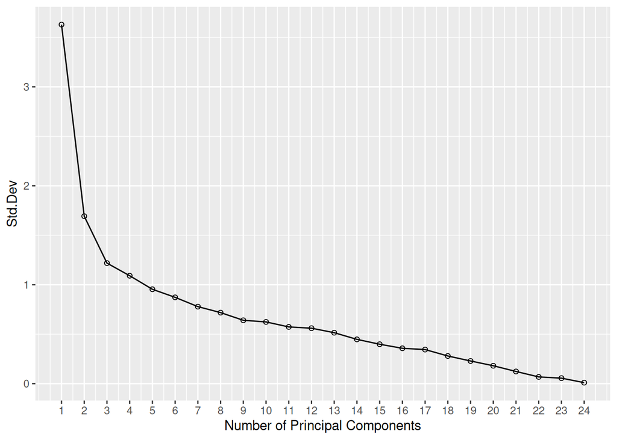

```r
scree = data.frame(Comp.Num=1:24, Std.Dev=summary(pcs)$sdev)

ggplot(scree, aes(x=Comp.Num, y=Std.Dev)) + geom_point(shape=1)+geom_line()+
  scale_x_continuous(name="Number of Principal Components", breaks=1:24,label=1:24)
```

There is a big drop off from comp 1 to 2. Drop from 2 to 3 is also considered big but later it slows down.

## Question 2

```r
pcs$loadings[,1:2]
```

```
##               Comp.1        Comp.2
## W       0.2485465821  0.0003339087
## L       0.2481305241  0.0049105577
## G       0.1157180074 -0.4490991329
## GS      0.2513671409  0.1860928982
## CG      0.1784603366  0.1201107167
## SHO     0.1597756082  0.1141041204
## SV      0.0001832465 -0.4759254475
## IPouts  0.2721370903  0.0023334717
## H       0.2695761762  0.0372229864
## ER      0.2633929965  0.0656695294
## HR      0.2398580115  0.0663094294
## BB      0.2553728491 -0.0219476071
## SO      0.2483056383 -0.0519737193
## BAOpp  -0.0498421826  0.2572994470
## ERA    -0.0601416398  0.2312392521
## IBB     0.1394325628 -0.2505227921
## WP      0.1847743602 -0.0563996982
## HBP     0.1850133992  0.0034962516
## BK      0.1074499166 -0.0016540247
## BFP     0.2733827824  0.0075140944
## GF     -0.0114332371 -0.5510927532
## R       0.2647693669  0.0624672026
## SH      0.2146123712 -0.0545526507
## SF      0.2137870088 -0.0122655273
```

I sadly don’t understand baseball but chatgpt explained me this about these components:

Component 1: This component mostly shows how much a pitcher is used. Pitchers with high scores here: Pitch a lot of innings. Start many games. Face a lot of batters. Collect lots of wins, losses, strikeouts, and walks.

So, Component 1 = “Workload” or “Starting Pitcher factor” (mostly starters who pitch a lot).

Component 2: This one separates pitching roles: Relievers/Closers: Low scores here (they tend to finish games and get saves). Starters or long relievers: Higher scores here. Also, some stats like ERA and opponent batting average (BAOpp) are more related to performance and go slightly positive here. So, Component 2 = “Reliever vs. Starter” factor.

## Question 3

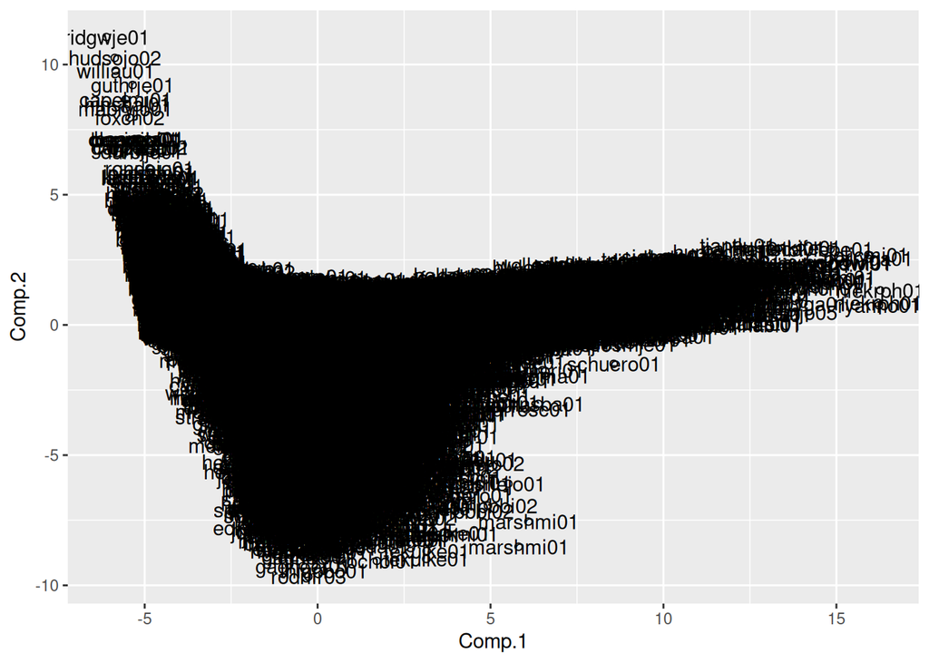

```r
pitchersPC=cbind(pitchers, pcs$scores[,1:2])
ggplot(pitchersPC, aes(x=Comp.1,y=Comp.2,label=playerID))+geom_point(shape=1)+geom_text()
```

This plot was very bad but I think we can say that there 3 major clusters. Players with high comp2 and negative comp1. Players in negative comp2 and kind of zero comp1. And people with high comp1 and zero ish comp 2